# Laboratorio 3

```python
import pandas as pd
import numpy as np
import matplotlib.pyplot as plt
import seaborn as sns
import scipy.stats as stats
from sklearn.neural_network import MLPClassifier
from sklearn.metrics import confusion_matrix
from sklearn.model_selection import train_test_split
from sklearn.metrics import accuracy_score, confusion_matrix
from sklearn.model_selection import GridSearchCV
from tensorflow.keras.utils import to_categorical
from tensorflow.keras.models import Sequential
from tensorflow.keras.layers import Dense
from PIL import Image
```

## 1. Analisis Exploratorio

```python
data = pd.read_csv('./digit-recognizer/train.csv')

data.head()
```

|  | label | pixel0 | pixel1 | pixel2 | pixel3 | pixel4 | pixel5 | pixel6 | pixel7 | pixel8 | ... | pixel774 | pixel775 | pixel776 | pixel777 | pixel778 | pixel779 | pixel780 | pixel781 | pixel782 | pixel783 |
| --- | --- | --- | --- | --- | --- | --- | --- | --- | --- | --- | --- | --- | --- | --- | --- | --- | --- | --- | --- | --- | --- |
| 0 | 1 | 0 | 0 | 0 | 0 | 0 | 0 | 0 | 0 | 0 | ... | 0 | 0 | 0 | 0 | 0 | 0 | 0 | 0 | 0 | 0 |
| 1 | 0 | 0 | 0 | 0 | 0 | 0 | 0 | 0 | 0 | 0 | ... | 0 | 0 | 0 | 0 | 0 | 0 | 0 | 0 | 0 | 0 |
| 2 | 1 | 0 | 0 | 0 | 0 | 0 | 0 | 0 | 0 | 0 | ... | 0 | 0 | 0 | 0 | 0 | 0 | 0 | 0 | 0 | 0 |
| 3 | 4 | 0 | 0 | 0 | 0 | 0 | 0 | 0 | 0 | 0 | ... | 0 | 0 | 0 | 0 | 0 | 0 | 0 | 0 | 0 | 0 |
| 4 | 0 | 0 | 0 | 0 | 0 | 0 | 0 | 0 | 0 | 0 | ... | 0 | 0 | 0 | 0 | 0 | 0 | 0 | 0 | 0 | 0 |

5 rows × 785 columns

```python
data.shape
```

```
(42000, 785)
```

```python
data.info()
```

```
<class 'pandas.core.frame.DataFrame'>
RangeIndex: 42000 entries, 0 to 41999
Columns: 785 entries, label to pixel783
dtypes: int64(785)
memory usage: 251.5 MB
```

```python
label_counts = {}
for x in data["label"]:
    if x not in label_counts:
        label_counts[x] = 1
    else:
        label_counts[x] += 1

print(label_counts)
```

```
{1: 4684, 0: 4132, 4: 4072, 7: 4401, 3: 4351, 5: 3795, 8: 4063, 9: 4188, 2: 4177, 6: 4137}
```

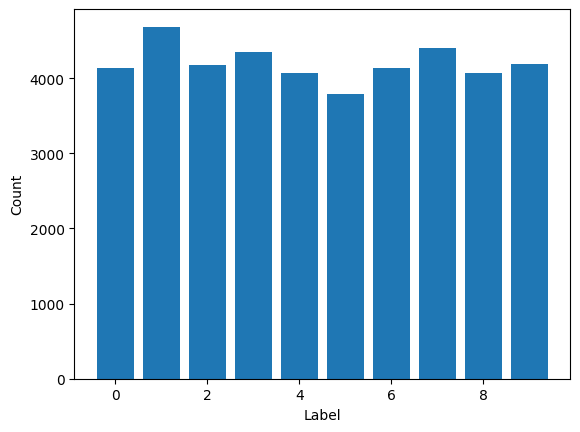

```python
plt.bar(label_counts.keys(), label_counts.values())
plt.xlabel('Label')
plt.ylabel('Count')
plt.show()
```

Al observar la grafica del conteo de labels se puede observar que el dataset se encuentra balanceado por lo que no es necesario realizar un balanceo de datos y se puede continuar con la clasificacion.

## 2. Modelo de Redes Neuronales Simples

```
Fitting 3 folds for each of 3 candidates, totalling 9 fits
Mejores hiperparámetros: {'hidden_layer_sizes': (50,)}
Accuracy: 94.43%
```

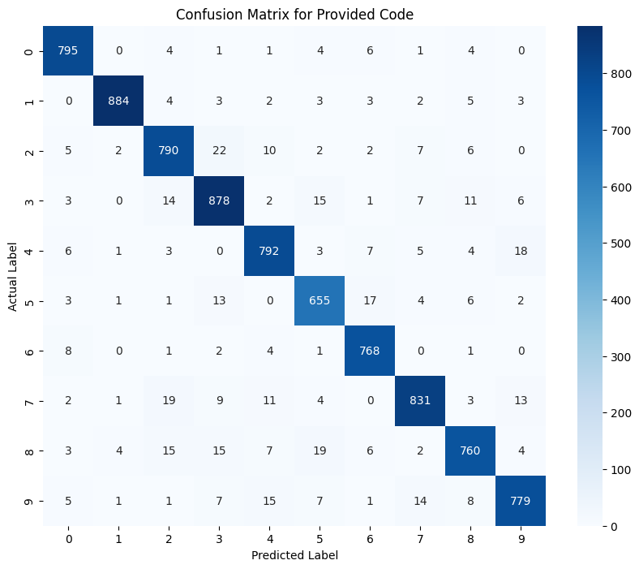

```python
y = data["label"]
X = data.drop("label", axis=1)
X_train, X_test, y_train, y_test = train_test_split(X, y, test_size=0.2, random_state=42)
param_grid_1 = {"hidden_layer_sizes":[(15,), (25,), (50,)]}

# Creación de la red neuronal

# Aquí estamos creando una red neuronal con una capa oculta de 5 neuronas
mlp = MLPClassifier(random_state=42)

grid_search = GridSearchCV(estimator=mlp, param_grid=param_grid_1, cv=3, n_jobs=-1, verbose=2, scoring='accuracy')
grid_search.fit(X_train, y_train)
print("Mejores hiperparámetros:", grid_search.best_params_)

best_mlp = grid_search.best_estimator_
y_pred = best_mlp.predict(X_test)

accuracy = accuracy_score(y_test, y_pred)
print(f"Accuracy: {accuracy * 100:.2f}%")

conf_mat = confusion_matrix(y_test, y_pred)

# Plot the confusion matrix using seaborn
plt.figure(figsize=(10, 8))
sns.heatmap(conf_mat, annot=True, fmt="d", cmap="Blues",
            xticklabels=list(range(10)), yticklabels=list(range(10)))
plt.ylabel('Actual Label')
plt.xlabel('Predicted Label')
plt.title('Confusion Matrix for Provided Code')
plt.show()
```

El mejor modelo de red neuronal simple es el que contiene 50 neuronas en la capa oculta, presentando una precisión de 0.94. Este modelo presenta varios errores en la clasificación de los datos. El error que más resalta es la clasificación erronea de los números 2 marcandolos como 3. Este error se presenta 22 veces en la predicción del modelo. Por otro lado, el modelo es bastante bueno clasificando 1 como 1, clasificando 884 datos correctamente.

## 3. Modelo de Deep Learning

```python
from keras.utils import to_categorical

# Separar las etiquetas y las imágenes
X_train_normalize = X_train.values / 255.0
X_test_normalize = X_test.values / 255.0
y_train_one_hot = to_categorical(y_train)
y_test_one_hot = to_categorical(y_test)

# Cambiar la forma de los datos de las imágenes
images = X_train_normalize.reshape(-1, 28, 28, 1)
images_test = X_test_normalize.reshape(-1, 28, 28, 1)

# Codificar las etiquetas en formato one-hot
```

```python
from keras.models import Sequential
from keras.layers import Conv2D, MaxPooling2D, Flatten, Dense

model = Sequential()

model.add(Conv2D(filters=32, kernel_size=(3, 3), activation='relu', input_shape=(28, 28, 1)))
model.add(MaxPooling2D(pool_size=(2, 2)))

model.add(Conv2D(filters=64, kernel_size=(3, 3), activation='relu'))
model.add(MaxPooling2D(pool_size=(2, 2)))

model.add(Flatten())
model.add(Dense(128, activation='relu'))
model.add(Dense(10, activation='softmax'))  # 10 clases de salida

model.compile(optimizer='adam', loss='categorical_crossentropy', metrics=['accuracy'])
```

```python
from tensorflow.keras.wrappers.scikit_learn import KerasClassifier
from sklearn.model_selection import RandomizedSearchCV

def create_model(optimizer='adam', filters=32):
    model = Sequential()
    model.add(Conv2D(filters=filters, kernel_size=(3, 3), activation='relu', input_shape=(28, 28, 1)))
    model.add(MaxPooling2D(pool_size=(2, 2)))
    model.add(Flatten())
    model.add(Dense(128, activation='relu'))
    model.add(Dense(10, activation='softmax'))
    model.compile(optimizer=optimizer, loss='categorical_crossentropy', metrics=['accuracy'])
    return model

model = KerasClassifier(build_fn=create_model)

param_dist = {
    'batch_size': [32, 64],
    'epochs': [10, 20]
}

random_search = RandomizedSearchCV(estimator=model, param_distributions=param_dist, n_iter=2)
random_search_results = random_search.fit(images, y_train_one_hot)
```

```python
# Usando los hiperparámetros obtenidos del proceso de afinación
best_params = random_search_results.best_params_

model = create_model()
history = model.fit(images, y_train_one_hot, batch_size=best_params['batch_size'], epochs=best_params['epochs'], validation_split=0.2)
```

```python
test_loss, test_accuracy = model.evaluate(images_test, y_test_one_hot)
print(f"Accuracy on test data: {test_accuracy * 100:.2f}%")
```

```
Accuracy on test data: 98.33%
```

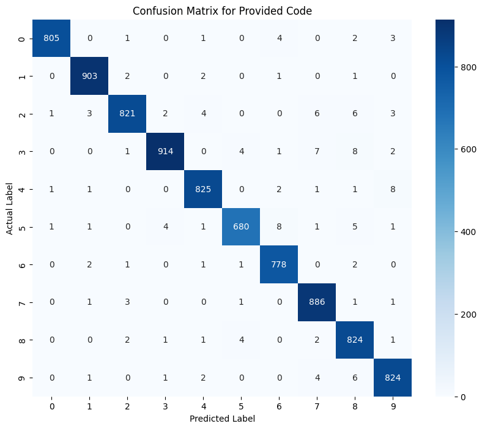

```python
y_pred_one_hot = model.predict(images_test)
y_pred = np.argmax(y_pred_one_hot, axis=1)

conf_mat_2 = confusion_matrix(y_test, y_pred)
# Plot the confusion matrix using seaborn
plt.figure(figsize=(10, 8))
sns.heatmap(conf_mat_2, annot=True, fmt="d", cmap="Blues",
            xticklabels=list(range(10)), yticklabels=list(range(10)))
plt.ylabel('Actual Label')
plt.xlabel('Predicted Label')
plt.title('Confusion Matrix for Provided Code')
plt.show()
```

## 4. Modelo Cualquiera

##### Random forest

El otro modelo que se utilizara es el de random forest. Este modelo se seleccionó debido a la capacidad de hacer varias predicciones debiles y combinarlas para obtener una predicción más precisa.

```
Fitting 3 folds for each of 3 candidates, totalling 9 fits
Mejores hiperparámetros: {'n_estimators': 200}
Accuracy: 96.36%
```

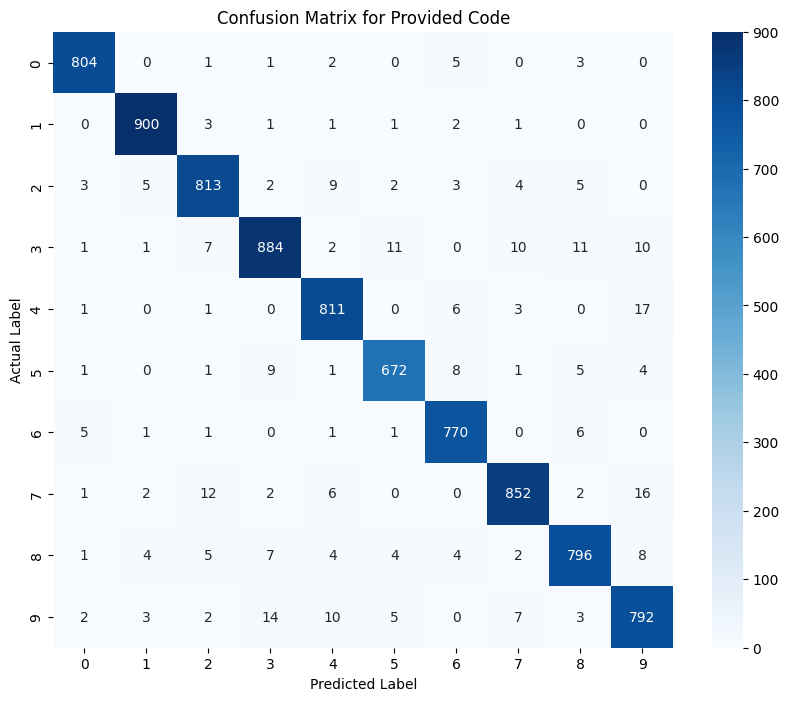

```python
from sklearn.model_selection import train_test_split
from sklearn.ensemble import RandomForestClassifier
from sklearn.metrics import accuracy_score
from sklearn.metrics import confusion_matrix

# Executing the provided code

# Cargando el conjunto de datos
param_grid_2 = {
    'n_estimators': [50, 100, 200]
}

rf = RandomForestClassifier(random_state=42)

grid_search = GridSearchCV(estimator=rf, param_grid=param_grid_2, cv=3, n_jobs=-1, verbose=2, scoring='accuracy')

grid_search.fit(X_train, y_train)
print("Mejores hiperparámetros:", grid_search.best_params_)

best_rf = grid_search.best_estimator_
y_pred = best_rf.predict(X_test)

# Calculando y mostrando la precisión
accuracy = accuracy_score(y_test, y_pred)
print(f"Accuracy: {accuracy * 100:.2f}%")

# Compute the confusion matrix for the provided code's predictions
conf_mat_3 = confusion_matrix(y_test, y_pred)

# Plot the confusion matrix using seaborn
plt.figure(figsize=(10, 8))
sns.heatmap(conf_mat_3, annot=True, fmt="d", cmap="Blues",
            xticklabels=list(range(10)), yticklabels=list(range(10)))
plt.ylabel('Actual Label')
plt.xlabel('Predicted Label')
plt.title('Confusion Matrix for Provided Code')
plt.show()
```

El mejor modelo de Random Forest tuvo una precisión de 0.96. Este modelo se confundió más con el label 4, marcadondolos como 9. Esto es seguido por el label 7, marcandolos como 9. Por otro lado, el modelo se confundió menos con el label 1 con 900 datos clasificados correctamente. Seguido por la clasificación del label 3.

El mejor modelo fue el de Deep Learning, con un accuracy de 0.98, seguido por el de Random Forest con un accuracy de 0.96 y por ultimo el de red neuronal simple con accuracy de 0.94. Por lo que para la siguiente parte se utilizará este modelo.

## 5. Prueba del mejor modelo

```python
images = ["./2.png", "./3.png", "./5.png", "./6.png", "./7.png"]
for imagen in images:
    image = Image.open(imagen).convert('L').resize((28, 28))
    image = np.array(image)
    invertedImage = 255 - image
    new_image = invertedImage.reshape(1, 28, 28, 1)
    y_pred = model.predict(new_image)
    print("Clase predicha: ", np.argmax(y_pred))
```

```
Clase predicha:  2
Clase predicha:  3
Clase predicha:  3
Clase predicha:  6
Clase predicha:  7
```

Al usar el modelo de Deep Learning para predecir los numeros hechos a mano pudo detectar correctamente 4 de los 5 numeros, el numero que no pudo detectar fue el 5, el cual fue confundido con el numero 3. Esto se debe a que el numero 5 tiene una forma muy similar al numero 3, por lo que el modelo no pudo diferenciarlos correctamente. Sin embargo el modelo pudo detectar correctamente los numeros 2, 3, 6 y 7.

## EJERCICIO 2

### Jonathan Espinoza 20022

### Manuel Archila 161250

```python
import numpy as np
import pandas as pd
from matplotlib import pyplot as plt
from statsmodels.tsa.seasonal import seasonal_decompose
from sklearn.preprocessing import StandardScaler
from keras.preprocessing.text import Tokenizer
from keras.preprocessing.sequence import pad_sequences
from sklearn.model_selection import train_test_split
from keras.utils import to_categorical
from keras.models import Sequential
from keras.layers import Dense, Dropout, Embedding, LSTM, GlobalMaxPooling1D, SpatialDropout1D
```

```python
def limpiar_y_convertir_a_float(valor_str):
    return float(valor_str.replace(',', ''))
```

```python
consumo = pd.read_csv('./consumo/Consumo.csv')
for column in consumo.columns:
    if column == 'Fecha':
       consumo['Fecha'] = consumo['Fecha'].replace({'ene-': 'Jan-','feb-': 'Feb-','mar-': 'Mar-','abr-': 'Apr-','may-': 'May-','jun-': 'Jun-','jul-': 'Jul-','ago-': 'Aug-','sep-': 'Sep-','oct-': 'Oct-','nov-': 'Nov-','dic-': 'Dec-'}, regex=True)
       consumo['Fecha'] = pd.to_datetime(consumo['Fecha'], format='%b-%y')
    else:
        if consumo[column].dtype == 'object':
            consumo[column] = consumo[column].apply(limpiar_y_convertir_a_float)


consumo["Diesel_conjunto"] = consumo["Diesel alto azufre"] + consumo["Diesel bajo azufre"]
consumo["Diesel_conjunto"] = consumo["Diesel_conjunto"].fillna(0)
consumo["Diesel_conjunto"] = consumo["Diesel_conjunto"].astype(float)
consumo.dropna(subset=["Diesel_conjunto"], inplace=True)
nans_por_columna = consumo.isna().sum()
consumo_copy = consumo.copy()
consumo.set_index('Fecha', inplace=True)
```

```python
numerics= ["Gasolina regular", "Gasolina superior", "Diesel_conjunto", "Gas licuado de petróleo"]
consumo_numerics = consumo[numerics]
```

```python
consumo_copy.head()
```

|  | Fecha | Aceites lubricantes | Asfalto | Bunker | Ceras | Combustible turbo jet | Diesel bajo azufre | Diesel ultra bajo azufre | Gas licuado de petróleo | Gasolina de aviación | ... | Mezclas\r\noleosas | Naftas | PetCoke | Petróleo crudo | Solventes | Butano | Diesel alto azufre | Orimulsión | Total | Diesel_conjunto |
| --- | --- | --- | --- | --- | --- | --- | --- | --- | --- | --- | --- | --- | --- | --- | --- | --- | --- | --- | --- | --- | --- |
| 0 | 2000-01-01 | 0.0 | 48446.0 | 296766.99 | 0.0 | 0.0 | 0.0 | 0.0 | 194410.48 | 1426.0 | ... | 0.0 | 0.0 | 0.0 | 0.0 | 0.0 | 0.0 | 634667.06 | 0.0 | 1750544.64 | 634667.06 |
| 1 | 2000-02-01 | 0.0 | 50597.0 | 328116.44 | 0.0 | 0.0 | 0.0 | 0.0 | 174710.55 | 1458.0 | ... | 0.0 | 0.0 | 0.0 | 0.0 | 0.0 | 0.0 | 642380.66 | 0.0 | 1773220.22 | 642380.66 |
| 2 | 2000-03-01 | 0.0 | 27593.0 | 368589.63 | 0.0 | 0.0 | 0.0 | 0.0 | 189234.07 | 1503.0 | ... | 0.0 | 0.0 | 0.0 | 0.0 | 0.0 | 0.0 | 699807.25 | 0.0 | 1909498.79 | 699807.25 |
| 3 | 2000-04-01 | 0.0 | 53794.0 | 396300.47 | 0.0 | 0.0 | 0.0 | 0.0 | 174330.61 | 1561.0 | ... | 0.0 | 0.0 | 0.0 | 0.0 | 0.0 | 0.0 | 586803.98 | 0.0 | 1800932.86 | 586803.98 |
| 4 | 2000-05-01 | 0.0 | 60137.0 | 449368.92 | 0.0 | 0.0 | 0.0 | 0.0 | 191745.15 | 1642.0 | ... | 0.0 | 0.0 | 0.0 | 0.0 | 0.0 | 0.0 | 656948.20 | 0.0 | 1941771.90 | 656948.20 |

5 rows × 24 columns

```python
df_consumo_numerics = consumo_numerics.reset_index()
df_test_consumo = consumo_numerics.reset_index()

df_consumo_train = df_consumo_numerics[df_consumo_numerics['Fecha']<= '2020-12-31']
df_test_consumo = df_test_consumo[df_test_consumo['Fecha'] > '2020-12-31']
```

```python
df_consumo_train = pd.concat([df_consumo_train['Fecha'], df_consumo_train['Diesel_conjunto']], axis=1, join="inner")
df_consumo_train.set_index('Fecha', inplace=True)
df_consumo_train.tail()
```

| Fecha | Diesel_conjunto |
| --- | --- |
| 2020-08-01 | 885200.72 |
| 2020-09-01 | 959013.35 |
| 2020-10-01 | 1064005.30 |
| 2020-11-01 | 1072873.46 |
| 2020-12-01 | 1276290.85 |

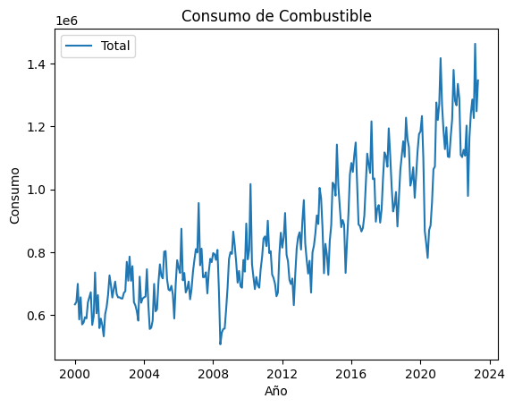

```python
plt.plot(df_consumo_numerics["Fecha"], df_consumo_numerics['Diesel_conjunto'], label=column)
plt.gca().set(title='Consumo de Combustible', ylabel='Consumo', xlabel='Año')
plt.legend()
plt.show()
```

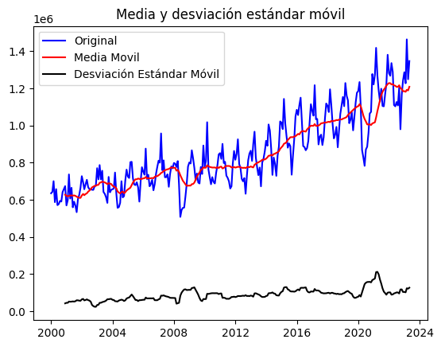

```python
mediaMovil = df_consumo_numerics['Diesel_conjunto'].rolling(window=12).mean()
deMovil = df_consumo_numerics['Diesel_conjunto'].rolling(window=12).std()
# Se grafican los resultados.
original = plt.plot( df_consumo_numerics['Fecha'], df_consumo_numerics['Diesel_conjunto'], color="blue", label="Original")
media = plt.plot(df_consumo_numerics['Fecha'], mediaMovil, color='red', label = 'Media Movil')
ds = plt.plot(df_consumo_numerics['Fecha'], deMovil, color='black', label = 'Desviación Estándar Móvil')
plt.legend(loc = 'best')
plt.title('Media y desviación estándar móvil')
plt.show(block=False)
```

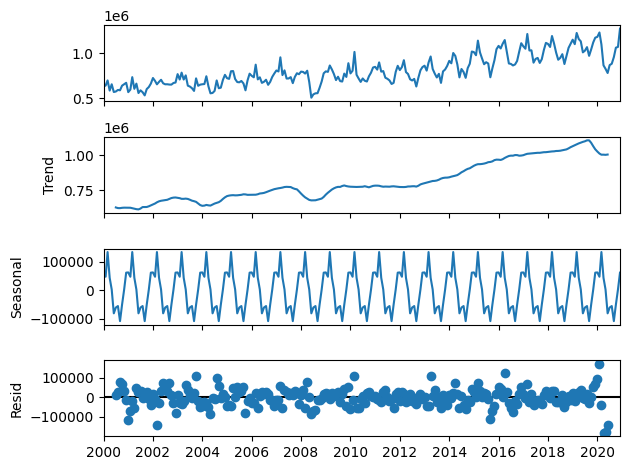

```python
descomposicion = seasonal_decompose(df_consumo_train)
descomposicion.plot()
plt.show()
```

Como la serie de tiempo muestra tendencia no es estacionaria en media ni varianza. Por lo que para estacionarizarla es necesario transformarla.

```python
from statsmodels.tsa.stattools import adfuller

# Calculate the result
result = adfuller(df_consumo_train['Diesel_conjunto'])

# Print the result
print(f'ADF Statistic: {result[0]}')
print(f'p-value: {result[1]}')
```

```
ADF Statistic: -0.8083576884485932
p-value: 0.8166547237213195
```

```python
diff = df_consumo_train['Diesel_conjunto'].diff()
diff.dropna(inplace=True)

result = adfuller(diff)

# Print the result
print(f'ADF Statistic: {result[0]}')
print(f'p-value: {result[1]}')
```

```
ADF Statistic: -6.575061240858315
p-value: 7.762667997716584e-09
```

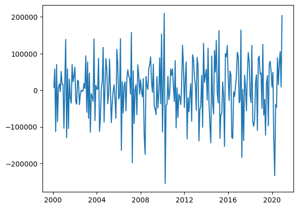

```python
plt.plot(diff)
plt.show()
```

Según la grafica, luego de las transoformaciones aplicadas, la serie es estacionaria tanto en media como en varianza.

Las redes neuronales trabajan mejor con los datos normalizados así que vamos a normalizar la serie:

```python
df_train_diff = df_consumo_train.diff()
df_train_diff.dropna(inplace=True)
scaler = StandardScaler()
consumo_diff = scaler.fit_transform(df_train_diff)
consumo_diff
```

[output not shown]

[output cut: 196 more lines]

```
       [ 8.73992306e-01],
       [ 9.88011466e-01],
       [ 6.50949625e-01],
       [ 7.92240660e-02],
       [ 5.97266620e-01],
       [-1.74234557e+00],
       [-3.04317354e+00],
       [-5.34407416e-01],
       [-6.32082495e-01],
       [ 1.10316579e+00],
       [ 1.58620828e-01],
       [ 9.19702813e-01],
       [ 1.32213297e+00],
       [ 8.14672953e-02],
       [ 2.59250595e+00]])
```

Vamos a separar la serie en entrenamiento, validación y prueba. En este caso, tendremos 80% para entrenamiento y 20% para validación.

```python
entrenamiento = round(0.8*(len(consumo_diff)-1))
val_prueba = round(0.2*len(consumo_diff)-1)
validation = consumo_diff[(entrenamiento):entrenamiento+val_prueba+1]
train = consumo_diff[0:entrenamiento]
train=np.insert(train,0,0)
train=np.reshape(train,(train.shape[0],1))

len(validation)
```

```
50
```

Para que pueda usarse el argoritmo LSTM es necesario transformar la serie en una supervisada, de manera que las observaciones anteriores sean capaces de estimar la siguiente. En este caso vamos a usar el mes anterior para predecir el siguiente por lo que vamos a transformar el arreglo de numpy en una matriz de dos dimensiones en la que la dimensión 1 sea el instante t-1 y la dimensión 2 sea el instante t

```python
from operator import concat


def supervisada(serie,retrasos = 1):
    serie_x = []
    serie_y = []
    for i in range(len(serie)-retrasos):
        valor = serie[i:(i+retrasos),0]
        valor_sig = serie[i+retrasos,0]
        serie_x.append(valor)
        serie_y.append(valor_sig)
    return np.array(serie_x), np.array(serie_y)

x_train,y_train = supervisada(train)
x_val,y_val = supervisada(validation)
```

```python
x_train = np.reshape(x_train,(x_train.shape[0],1,1))
x_val = np.reshape(x_val, (x_val.shape[0],1,1))

len(x_val)
```

```
49
```

```python
modelo1 = Sequential()
lote = 1
unidades =  1
paso = 1
caracteristicas = 1 #es univariada
modelo1.add(LSTM(lote, batch_input_shape=(lote,paso,caracteristicas),stateful=True))
modelo1.add(Dense(1))
modelo1.summary()
```

```
Model: "sequential"
_________________________________________________________________
 Layer (type)                Output Shape              Param #
=================================================================
 lstm (LSTM)                 (1, 1)                    12

 dense (Dense)               (1, 1)                    2

=================================================================
Total params: 14 (56.00 Byte)
Trainable params: 14 (56.00 Byte)
Non-trainable params: 0 (0.00 Byte)
_________________________________________________________________
```

```python
modelo1.compile(loss='mean_squared_error',optimizer="rmsprop")
```

```python
epochs = 50
history= modelo1.fit(
    x = x_train,
    y = y_train,
    batch_size = lote,
    epochs = epochs,
    shuffle = False,
    validation_data = (x_val,y_val),
    verbose=1
)
```

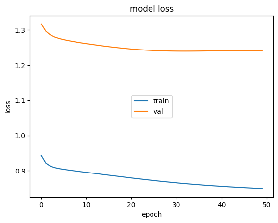

```python
plt.plot(history.history['loss'])
plt.plot(history.history['val_loss'])
plt.title('model loss')
plt.ylabel('loss')
plt.xlabel('epoch')
plt.legend(['train', 'val'], loc='center')
```

```python
df_test_consumo = consumo_numerics.reset_index()
df_test_consumo = df_test_consumo[df_test_consumo['Fecha'] > '2020-12-31']
df_test_consumo = pd.concat([df_test_consumo['Fecha'], df_test_consumo['Diesel_conjunto']], axis=1, join="inner")
df_test_consumo.set_index('Fecha', inplace=True)

df_test_diff = df_test_consumo.diff()
df_test_diff.dropna(inplace=True)
consumo_diff_test = scaler.fit_transform(df_test_diff)
```

```python
x_test,y_test = supervisada(consumo_diff_test)
x_test = np.reshape(x_test, (x_test.shape[0],1,1))
```

```python
prediccion_val = []
df_consumo = pd.concat([df_consumo_numerics['Fecha'], df_consumo_numerics['Diesel_conjunto']], axis=1, join="inner")
df_consumo = df_consumo.dropna()
df_consumo.set_index('Fecha', inplace=True)

def prediccion_fun(data, modelo, batch_size, scaler, dif=False, dif_cant=1, Series=None, n=1):
    prediccion = [0] * (len(data))
    series_length = len(Series)
    i = 0
    for X in data:
        X = np.reshape(X, (1, 1, 1))
        yhat = modelo.predict(X, batch_size=batch_size, verbose=0)
        yhat = scaler.inverse_transform(yhat)
        if dif:
            # Calculate index and make sure it's within bounds
            index = min(n + dif_cant * i, series_length - 1)
            yhat = yhat + Series[index]
        prediccion[i] = yhat[0][0]
        i = i + 1
    return prediccion

prediccion_val = prediccion_fun(x_val,modelo1, 1,scaler,dif=True,dif_cant=1, Series = df_consumo.values , n=entrenamiento)
prediccion_test = prediccion_fun(x_test,modelo1, 1,scaler,dif=True,dif_cant=1, Series = df_consumo.values , n=((len(df_consumo)- len(x_test))))
```

```python
df_val = pd.DataFrame(prediccion_val,index=df_consumo[(entrenamiento):(entrenamiento+val_prueba)].index)
df_test = pd.DataFrame(prediccion_test,index=df_consumo[(len(df_consumo)- len(x_test)):len(df_consumo)].index)
```

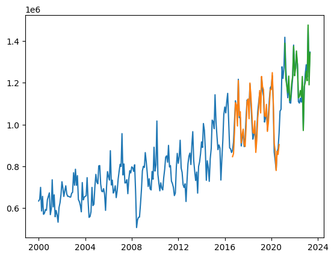

```python
plt.plot(df_consumo)
plt.plot(df_val)
plt.plot(df_test)
```

### Modelo 2

```python
modelo2 = Sequential()

modelo2.add(LSTM(50, batch_input_shape=(lote, paso, caracteristicas), stateful=True, return_sequences=True))
modelo2.add(Dropout(0.2))
modelo2.add(LSTM(50, return_sequences=True, stateful=True))
modelo2.add(Dropout(0.2))
modelo2.add(LSTM(50, stateful=True))
modelo2.add(Dropout(0.2))

modelo2.add(Dense(1))
modelo2.summary()
```

```
Model: "sequential_1"
_________________________________________________________________
 Layer (type)                Output Shape              Param #
=================================================================
 lstm_1 (LSTM)               (1, 1, 50)                10400

 dropout (Dropout)           (1, 1, 50)                0

 lstm_2 (LSTM)               (1, 1, 50)                20200

 dropout_1 (Dropout)         (1, 1, 50)                0

 lstm_3 (LSTM)               (1, 50)                   20200

 dropout_2 (Dropout)         (1, 50)                   0

 dense_1 (Dense)             (1, 1)                    51

=================================================================
Total params: 50851 (198.64 KB)
Trainable params: 50851 (198.64 KB)
Non-trainable params: 0 (0.00 Byte)
_________________________________________________________________
```

```python
modelo2.compile(optimizer='adam', loss='mean_squared_error', metrics=['accuracy'])
```

```python
epochs = 50
history= modelo2.fit(
    x = x_train,
    y = y_train,
    batch_size = lote,
    epochs = epochs,
    shuffle = False,
    validation_data = (x_val,y_val),
    verbose=1
)
```

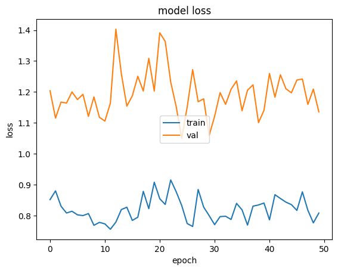

```python
plt.plot(history.history['loss'])
plt.plot(history.history['val_loss'])
plt.title('model loss')
plt.ylabel('loss')
plt.xlabel('epoch')
plt.legend(['train', 'val'], loc='center')
```

```python
prediccion_val = prediccion_fun(x_val,modelo2, 1,scaler,dif=True,dif_cant=1, Series = df_consumo.values , n=entrenamiento)
prediccion_test = prediccion_fun(x_test,modelo2, 1,scaler,dif=True,dif_cant=1, Series = df_consumo.values , n=((len(df_consumo)- len(x_test))))
```

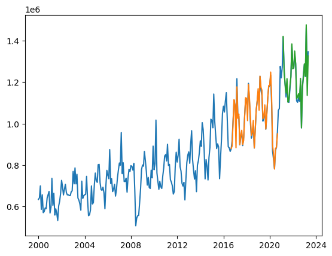

```python
df_val2 = pd.DataFrame(prediccion_val,index=df_consumo[(entrenamiento):(entrenamiento+val_prueba)].index)
df_test2 = pd.DataFrame(prediccion_test,index=df_consumo[(len(df_consumo)- len(x_test)):len(df_consumo)].index)

plt.plot(df_consumo)
plt.plot(df_val2)
plt.plot(df_test2)
```

### Calcular MSE

```python
from sklearn.metrics import mean_squared_error
```

```python
res = mean_squared_error(df_consumo[(entrenamiento):(entrenamiento+val_prueba)].values, df_val2.values)
res2 = mean_squared_error(df_consumo[(len(df_consumo)- len(x_test)):len(df_consumo)].values, df_test2.values)

res = np.sqrt(res)
res2 = np.sqrt(res2)

print('RMSE validation: ' + str(res))
print('RMSE test: ' + str(res2))
```

```
RMSE validation: 29754.98072604695
RMSE test: 25572.916744990158
```

```python
res = mean_squared_error(df_consumo[(entrenamiento):(entrenamiento+val_prueba)].values, df_val.values)
res2 = mean_squared_error(df_consumo[(len(df_consumo)- len(x_test)):len(df_consumo)].values, df_test.values)


res = np.sqrt(res)
res2 = np.sqrt(res2)

print('RMSE validation: ' + str(res))
print('RMSE test: ' + str(res2))
```

[output not shown]

## ¿Cuál predijo mejor?¿Son mejores que los modelos creados en el laboratorio pasado?¿Cómo lo determinaron?

Para este caso, ambas redes tuvieron resultados similares. Sin embargo, se observa como el modelo 2 de LSTM obtuvo mejores resultados en cuanto a predicciones de la serie de tiempo 'Consumo'. Se logra observar tambien, que ambos modelos obtuvieron mejores resultados que los realizados en el laboratorio pasado en donde se obtuvieron RMSE mayores a 100,000 mientras en este se obtuvieron valores mucho más precisos a los verdaderos.